# Homework DV4

## Question 5

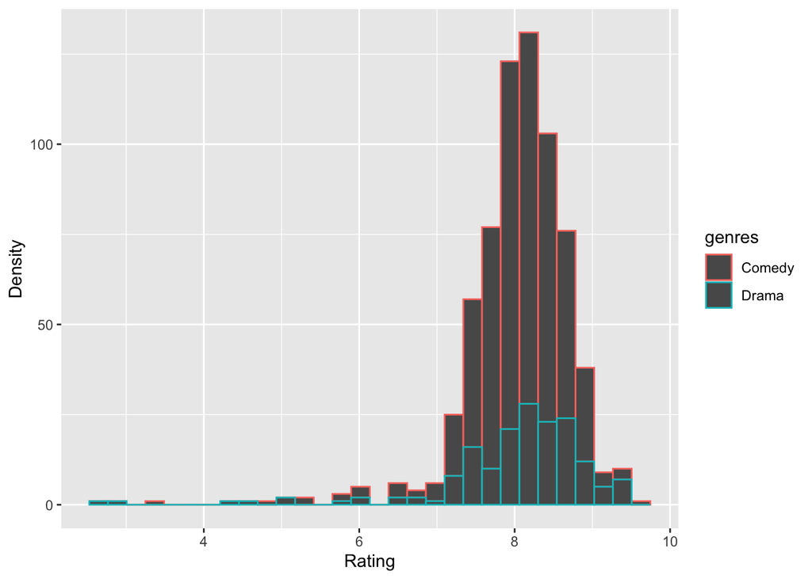

```r
comedies_dramas <- tv_ratings %>%
  mutate(is_comedy = if_else(str_detect(genres, "Comedy"),
                             1,
                             0)) %>% # If it contains the word comedy then 1, else 0
  filter(is_comedy == 1 | genres == "Drama") %>% # Keep comedies and dramas
  mutate(genres = if_else(genres == "Drama", # Make it so that we only have those two genres
                          "Drama",
                          "Comedy"))
ggplot(data = comedies_dramas,
       aes(x = av_rating, group = genres, color = genres)) +
  geom_histogram() +
  labs(x = "Rating", y = "Density")
```

Based on the bin sizes, this histogram tells me that many of the dramas and comedies were given a rating between 7 and 9.

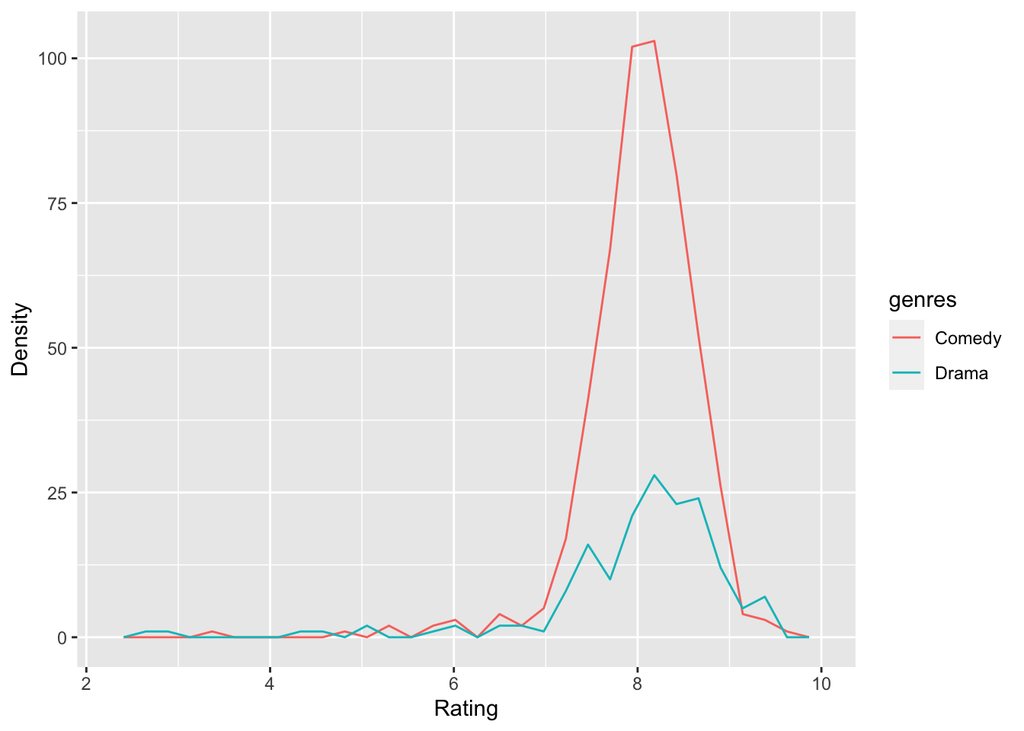

```r
comedies_dramas <- tv_ratings %>%
  mutate(is_comedy = if_else(str_detect(genres, "Comedy"),
                             1,
                             0)) %>% # If it contains the word comedy then 1, else 0
  filter(is_comedy == 1 | genres == "Drama") %>% # Keep comedies and dramas
  mutate(genres = if_else(genres == "Drama", # Make it so that we only have those two genres
                          "Drama",
                          "Comedy"))
ggplot(data = comedies_dramas,
       aes(x = av_rating, group = genres, color = genres)) +
  geom_freqpoly() +
  labs(x = "Rating", y = "Density")
```

## Question 6

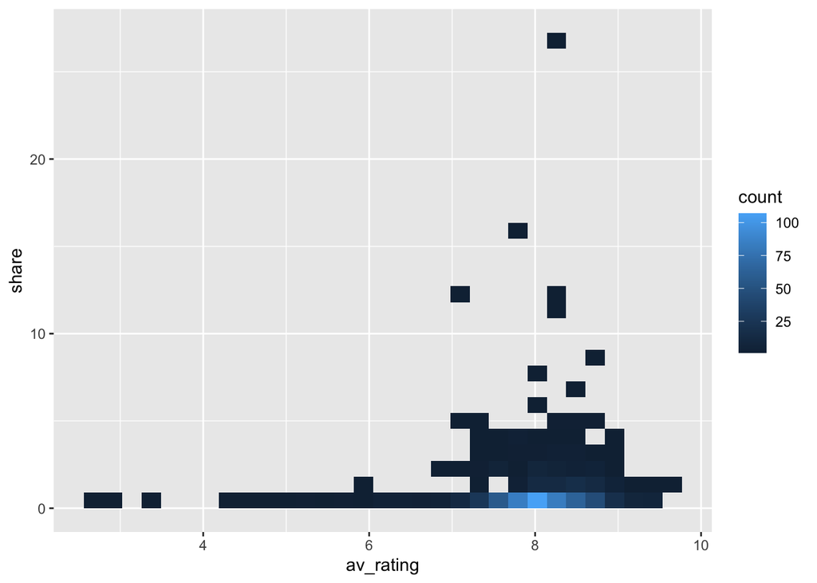

```r
ggplot(data = comedies_dramas,
       mapping = aes(x = av_rating, y = share)) +
  geom_bin2d()
```

From this data, I see that the number of shares is quite low, despite the high ratings. In comparison to a scatter plot, type of plot allows you to see how many people are actually watching these shows, no matter the rating.

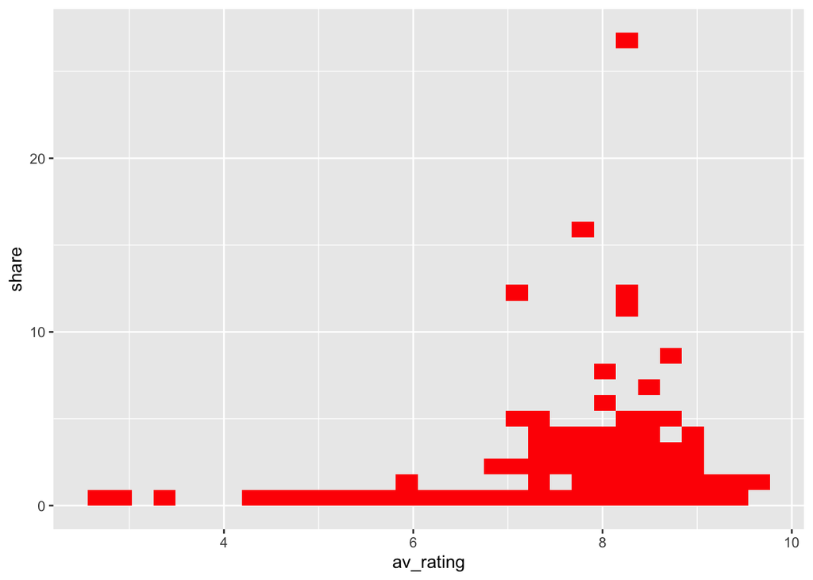

```r
ggplot(data = comedies_dramas,
       mapping = aes(x = av_rating, y = share)) +
  geom_bin2d(fill = "red")
```

A drama called ‘Dekalog’ is the outlier that with a rating of ~8.2 with ~27 shares.